# Python `break` and `continue`

- In Python, `break` and `continue` statements can **alter the flow of a normal loop.**
- Loops iterate over a block of code until the test expression is **false**, *but sometimes **we wish to terminate the current iteration or even the whole loop without checking test expression.***
- The `break` and `continue` statements are used in these cases.

### Python break statement

- The `break` statement **terminates the loop containing it.**
  - **Control of the program flows to the statement immediately after the body of the loop.**
- If the `break` statement is inside a nested loop (loop inside another loop), the `break` **statement will terminate the innermost loop.**

**Syntax of break**

break

```python
from IPython.display import Image
Image('break.jpg', width = 400, height = 500)
```

[output not shown]

**Working of `break` in `for` loop and `while` loop**

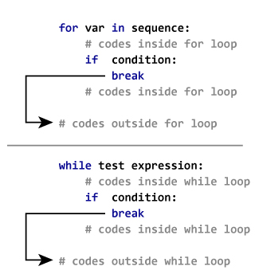

```python
Image('how-break-statement-works.jpg', width = 500, height = 800)
```

**Example of `break` statment**

```python
# Use of break statement inside the loop

for val in "string":
    if val == "i":
        break
    print(val)

print("Reached i in string 👍, So came out of the above loop") #Outside the loop
```

```
s
t
r
Reached i in string 👍, So came out of the above loop
```

- In this program, we iterate through the `"string"` sequence. We check if the letter is `i`, upon which we **`break`** from the loop.
- Hence, we see in our output that all the letters up till i gets printed. After that, the loop terminates.

### Python continue statement

- The **`continue`** statement is **used to skip the rest of the code inside a loop for the current iteration only.**
  - *Loop does not terminate but continues on with the next iteration.*

**Syntax of Continue**

continue

**Python `continue` flowchart**

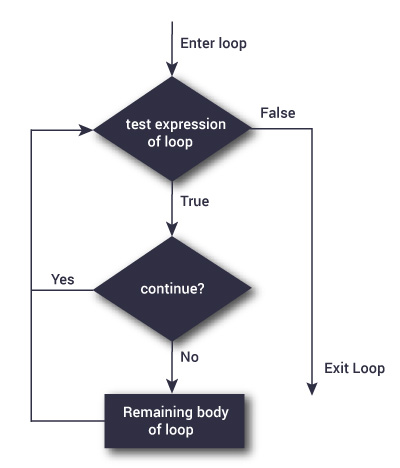

```python
Image('continue-statement-flowchart.jpg', width = 400, height = 600)
```

**Working of `continue` statement in `for` and `while` loop**

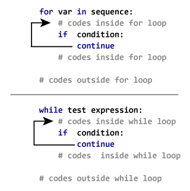

```python
Image("how-continue-statment-works.jpg", width = 500, height = 800)
```

**Example of `continue` statement**

```python
# Program to show the use of continue statement inside loops

for val in "string":
    if val == "i":
        continue
    print(val)

print("The end")
```

```
s
t
r
n
g
The end
```

- This program is same as the above example except the `break` statement has been replaced with `continue`.
- We `continue` with the loop, if the string is `i`, **not executing the rest of the block.**
  - Hence, we see in our output that **all the letters except `i` gets printed.**

# Python `pass`

- It is used as a **placeholder for future implementation of functions, loops, etc.**
- In Python programming, the **`pass` statement is a null statement.**
- *The difference between a **`comment`** and a **`pass`** statement in Python is that while the __interpreter ignores a `comment` entirely, `pass` is not ignored.*
- However, **nothing happens when the `pass` is executed.**
  - It results in **no operation (NOP).**

**Syntax of pass**

pass

**We generally use it as a placeholder.**

- Suppose we have a loop or a function that is not implemented yet, but we want to implement it in the future. They cannot have an empty body. The interpreter would give an error. So, we use the `pass` statement **to construct a body that does nothing.**

**Example: pass Statement**

```python
'''pass is just a placeholder for
functionality to be added later.'''

sequence = {'p', 'a', 's', 's'}

for val in sequence:
    pass
```

We can do the same thing in an empty function or class as well.

```python
def function(args):
    pass

class Example:
    pass
```